# Worksheet 5

Published

October 8, 2025

Questions are below. My solutions will be available after the tutorials are all finished. The whole point of these worksheets is for you to use your lecture notes to figure out what to do. In tutorial, the TAs are available to guide you if you get stuck. Once you have figured out how to do this worksheet, you will be prepared to tackle the assignment that depends on it.

If you are not able to finish in an hour, I encourage you to continue later with what you were unable to finish in tutorial.

Packages you’ll need:

```r
library(tidyverse)
```

## Power and the exponential distribution

The exponential distribution is often used to model lifetimes of things like light bulbs or electronic components. It is not normal (bell-curved) in shape. In R, the function `rexp` will draw a random sample from an exponential distribution. It has two inputs, the sample size, and the “rate” (which is one over the mean).

1. Draw a random sample of 100 observations from an exponential distribution with mean 5, saved as one column of a dataframe, and make a histogram of your sample. In what way is the distribution not normal in shape? Hint 1: `tibble` with the same sort of code as in a `mutate` will create a dataframe from scratch. Hint 2: use a `set.seed` first so that your random sample won’t change from one run to the next. You can use any number as input to the `set.seed`.

This is my `set.seed`:

```r
set.seed(457299)
```

You should probably get into the habit of using your own random number seed.

Use `tibble` and the definition to create a dataframe. The second input is $1/5 = 0.2$; it is easiest to let R do the calculation for you:

```r
expo <- tibble(x = rexp(100, 1/5))
```

We don’t know what the application is, so you can use “indefinite” names like mine.

A histogram via code such as this:

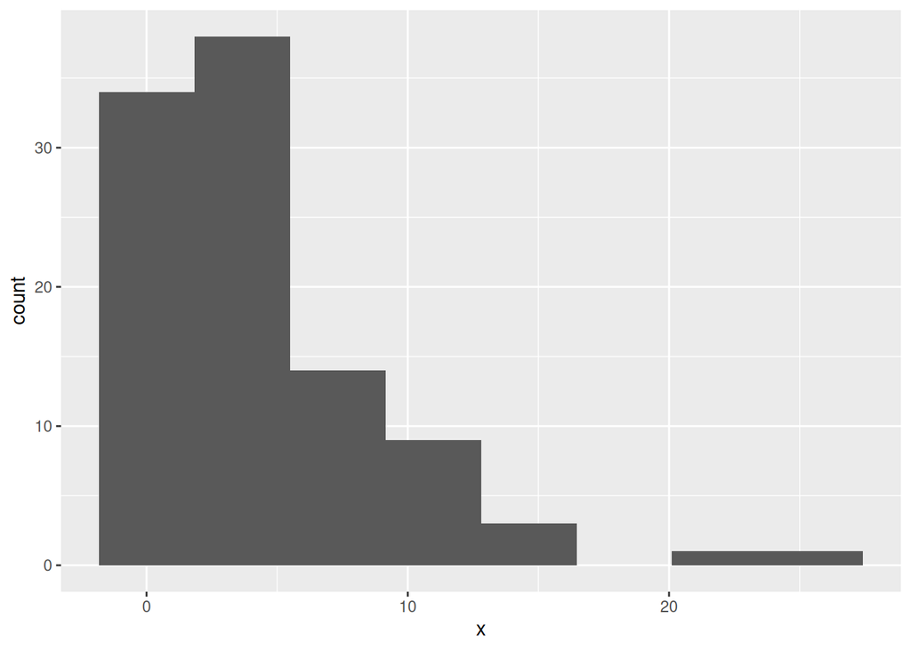

```r
ggplot(expo, aes(x = x)) + geom_histogram(bins = 8)
```

This number of bins shows the shape well for me. Yours will be different, so you might need a different number of bins.

This fails to be normally-distributed because it is skewed to the right. (Yours should have the same shape even if it looks a bit different. The sample size is big, so your sample should be a reasonable representation of the actual distribution, which has this shape.)

2. For your sample, obtain a bootstrap sampling distribution of the sample mean. Comment briefly on its shape.

This is the same procedure as in lecture. Make a new dataframe to hold the simulations, and then sample from your one column in your dataframe (whatever you called the column and the dataframe). Mine, therefore, goes like this:

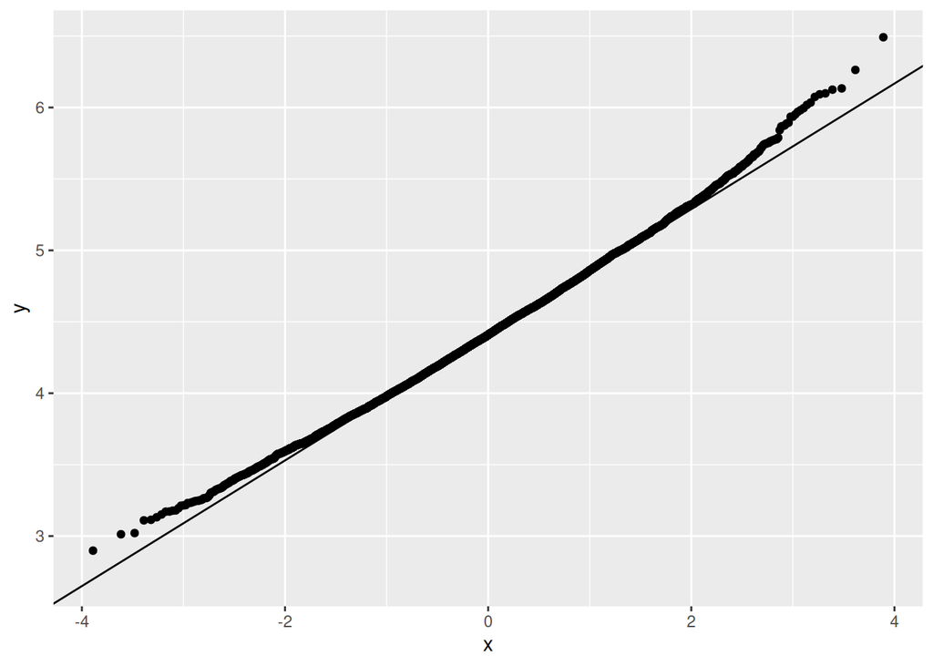

```r
tibble(sim = 1:10000) %>%
  rowwise() %>%
  mutate(my_sample = list(sample(expo$x, replace = TRUE))) %>%
  mutate(my_mean = mean(my_sample)) %>%
  ggplot(aes(sample = my_mean)) + stat_qq() + stat_qq_line()
```

I used 10,000 simulations because I am drawing a normal quantile plot at the end, and if you use fewer simulations, you can get deceived by the tails then. You could do fewer simulations and then draw a histogram, but then you have the more difficult job of assessing the histogram for normality (“is it bell-shaped?”). If you draw a normal quantile plot, all you have to do is to compare the points and the line.

Mine looks very slightly right-skewed (it has a slight but definite curve), but it is close to normal (close to the line). Yours will be different because you’ll have a different random sample, but I’m expecting that you will see something very similar.

Extra: these questions were from an old assignment, and at that time I didn’t show you the normal quantile plot until later in the course. Had I not asked you to draw a histogram, you could reasonably also have drawn a normal quantile plot of the original data, which looks like this (for me):

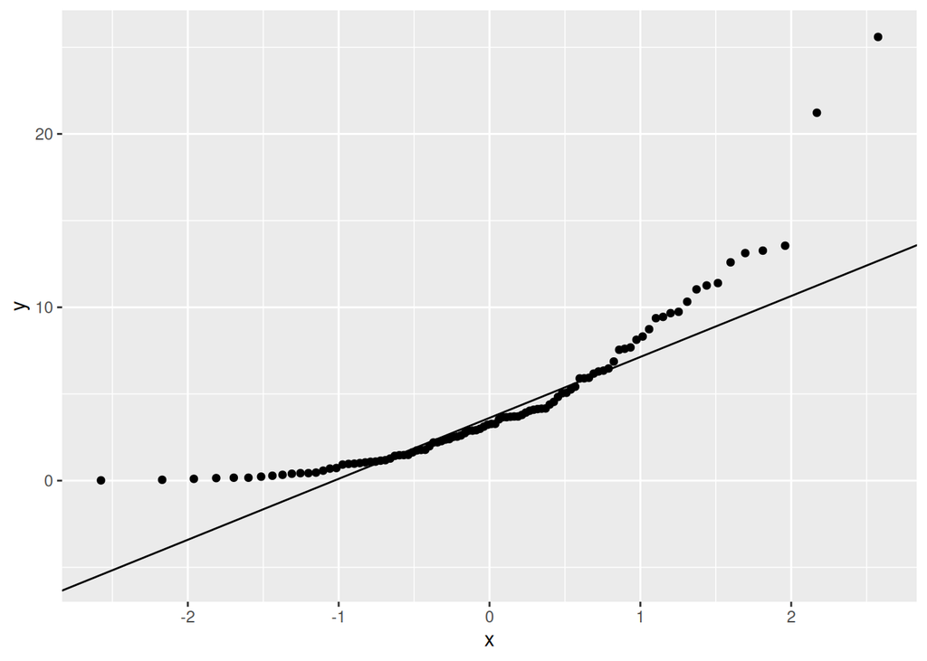

```r
ggplot(expo, aes(sample = x)) + stat_qq() + stat_qq_line()
```

This perhaps makes the point better that the original data were *very* right-skewed (a big-time curve), but the bootstrap sampling distribution of the sample mean is much closer to normal, because we have a large sample ($n = 100$) and therefore the Central Limit Theorem is helping a lot. You might say that a sample of size 100 is big enough, or almost big enough, to overcome even that considerable right-skewness.

3. Explain briefly why it makes sense to use a (one-sample) $t$-test for the population mean, even though the population does not appear to have a normal distribution.

The sampling distribution of the sample mean is normal (or close to normal) even though the distribution of the sample is very much not: the sample size is (almost) large enough to overcome the non-normality in the sample. (“The sample is large” is not a complete answer, because it doesn’t say how the large sample size helps.)

If your simulated sampling distribution is skewed right too much for your tastes, you’ll have to use words like “close to normal” to justify using a $t$-test here (which would imply that the P-value is close to correct even if it is not bang on).

4. Estimate by simulation the power of a one-sample $t$-test to reject the null hypothesis that the population mean is 6 (against a two-sided alternative), when sampling from an exponential distribution with mean 5 and using a sample of size 100.

This one has the same ingredients as the one in lecture, but is not exactly the same, because we are not sampling from a normal distribution here:

```r
tibble(sim = 1:1000) %>%
  rowwise() %>%
  mutate(my_sample = list(rexp(100, 1/5))) %>%
  mutate(t_test = list(t.test(my_sample, mu = 6))) %>%
  mutate(p_value = t_test$p.value) %>%
  count(p_value <= 0.05)
```

| p_value <= 0.05 | n |
| --- | --- |
| FALSE | 459 |
| TRUE | 541 |

The steps:

- set up a dataframe with places for 1000 simulations (or more)
- work rowwise
- generate random samples from the true distribution, exponential with the true mean (of 5). This is the same code (inside the `list`) as you wrote earlier.
- run a $t$-test on each of your simulated samples, testing that the mean is 6 (the null mean, which we know to be wrong). The output from `t.test` is a collection of things (the P-value, the sample mean, a confidence interval, etc.) so this needs to be wrapped in `list` (and will make a list-column).
- pull out the P-value from each $t$-test, which is a single number each time, so no `list` needed
- count how many of those P-values would lead to (correct) rejection of the (incorrect) null.

My estimated power is 0.541. I would expect yours to be somewhere within about 0.030 of that, with 1000 simulations. (If it is not, give your code a good look over, and make sure it is correct.)

Extra: Where did the 6 come from? In this case, out of my head,[^1] but in general, this is the “subject matter knowledge” thing: a subject matter expert tells us what null hypothesis would usually be tested in this situation (the 6) and what sort of difference from that would be considered a scientifically interesting departure (the 5, 1 away).

I wanted to lead you through the process, so I started you off by generating a random sample from what was going to be the truth and introduced the null mean of 6 later, which is perhaps backwards. The logical way to think about power is that the null hypothesis represents the “standard theory” (6 here) and we are trying to see how likely we are to reject that null hypothesis when the truth is actually something else far enough from that null hypothesis to be of interest (5 here).

5. Suppose our aim is to estimate (by simulation) the sample size needed to get a power of 0.75 in this same situation. By copying and pasting your code and making a small edit to it, run another simulation that will go some way towards meeting that aim. (This was previously an assignment question, so I made it definite about what to do, but on a worksheet, feel free to experiment further after you have tried your one more simulation.)

In my case (and probably yours), the power came out less than 0.75, so to achieve this much power, we will need a bigger sample size. The problem with the simulation approach is that we have *no idea* how much bigger the sample size needs to be, so to answer this question, copy and paste your code and change the sample size in the `rexp` line to any number at all bigger than 100, for example:

```r
tibble(sim = 1:1000) %>%
  rowwise() %>%
  mutate(my_sample = list(rexp(200, 1/5))) %>%
  mutate(t_test = list(t.test(my_sample, mu = 6))) %>%
  mutate(p_value = t_test$p.value) %>%
  count(p_value <= 0.05)
```

| p_value <= 0.05 | n |
| --- | --- |
| FALSE | 219 |
| TRUE | 781 |

This will get your power closer to 0.75. It doesn’t have to be much closer; any closer at all will do. I actually overshot some, so my next guess (if I were to make one) would be a sample size less than 200, but closer to 200 than 100 (say, something like 180). There is randomness here, so I can only hope to get so close. I actually was lucky enough to do pretty well.

You only needed one more simulation of this kind. You can do more if you want (but see the Extra below).

If your first simulation for some reason gave you a power greater than 0.75, your second guess at the sample size should be something *less* than 100 (again, it doesn’t matter exactly what).

Extra: I said we “can only get so close”. To think about how close we might be to the “true power” (whatever it is), note that each simulated sample either leads to us correctly rejecting the null (success) or failing to reject the null and making a type II error (failure). Then we have 1000 of those repeated trials, and we count how many times we succeeded. My language here (“trial” with “success” and “failure”) is intended to remind you of a *binomial* distribution. Here we have $n = 1000$ trials (simulated samples), and a probability $p$ of correctly rejecting the null (that is the power we are trying to estimate). You might have run into a confidence interval formula for $p$, based on the number of trials and successes observed; this is encoded in the R function `prop.test`, which takes (for a confidence interval) two inputs, the number of successes and the number of trials.

For my first simulation, I got 541 successful rejections, so a 95% confidence interval for the true power is

```r
prop.test(541, 1000)
```

```
    1-sample proportions test with continuity correction

data:  541 out of 1000, null probability 0.5
X-squared = 6.561, df = 1, p-value = 0.01042
alternative hypothesis: true p is not equal to 0.5
95 percent confidence interval:
 0.5095159 0.5721653
sample estimates:
    p
0.541
```

From this simulation, the power is most likely between 0.510 and 0.572. (This is where I got my “within 0.030” above from.)

For my second simulation, I got 781 successful rejections out of 1000:

```r
prop.test(781, 1000)
```

```
    1-sample proportions test with continuity correction

data:  781 out of 1000, null probability 0.5
X-squared = 314.72, df = 1, p-value < 2.2e-16
alternative hypothesis: true p is not equal to 0.5
95 percent confidence interval:
 0.7537994 0.8060081
sample estimates:
    p
0.781
```

The confidence interval is between 0.754 and 0.806. We were aiming for a power of 0.75, so now we know that a sample size of 200 is indeed too big, but it may not be much too big.

To get this confidence interval shorter, we need to do more simulations, like 10,000. Let me have a third go, using a sample size of 180 and 10,000 simulations:

```r
tibble(sim = 1:10000) %>%
  rowwise() %>%
  mutate(my_sample = list(rexp(180, 1/5))) %>%
  mutate(t_test = list(t.test(my_sample, mu = 6))) %>%
  mutate(p_value = t_test$p.value) %>%
  count(p_value <= 0.05)
```

| p_value <= 0.05 | n |
| --- | --- |
| FALSE | 2563 |
| TRUE | 7437 |

That you can see is really close (0.7437) to 0.75. We would expect the confidence interval for the true power to (i) be shorter (more simulations), and (ii) to contain 0.75:

```r
prop.test(7437, 10000)
```

```
    1-sample proportions test with continuity correction

data:  7437 out of 10000, null probability 0.5
X-squared = 2374.6, df = 1, p-value < 2.2e-16
alternative hypothesis: true p is not equal to 0.5
95 percent confidence interval:
 0.7350000 0.7522117
sample estimates:
     p
0.7437
```

Between 0.735 and 0.752. We have now nailed down the power rather precisely, and we are not likely to get any closer than $n = 180$ as a sample size to achieve this power.

## Child psychology

According to research in child psychology, working mothers spend a mean time of 11 minutes per day talking to their children, with a standard deviation of 2.3 minutes. Your research suggests that the mean should be greater than that, and you are planning a study of working mothers (who work outside the home) to see how many minutes *they* spend talking to their children. You think that the mean should be 12 minutes per day, and you want to design your study so that a mean of 11 should be rejected with a reasonably high probability.

6. If you interview 20 working mothers, what is the power of your test if your thought about the mean is correct? Estimate by simulation. Assume that the time that a mother spends talking to her children has a normal distribution.

Then follow the familiar six lines of code:

```r
tibble(sim = 1:1000) %>%
  rowwise() %>%
  mutate(my_sample = list(rnorm(20, 12, 2.3))) %>%
  mutate(t_test = list(t.test(my_sample, mu = 11, alternative = "greater"))) %>%
  mutate(p_value = t_test$p.value) %>%
  count(p_value <= 0.05)
```

| p_value <= 0.05 | n |
| --- | --- |
| FALSE | 433 |
| TRUE | 567 |

The estimated power is $567/1000 = 0.567$. By interviewing 20 working mothers, you are likely to be able to reject the null hypothesis that the mean time spent talking to their children is 11 minutes per day, in favour of an alternative that the mean is larger than this.

Your answer will likely differ from mine by a bit (see below for how big “a bit” might be), but it should be somewhere near this.

The code:

- set up a data frame with places for 1000 (or 10,000 or whatever) simulated samples
- work one row at a time from here forward
- draw a random sample of size 20 *from the truth* (as far as you know what it is) for each row
- run a $t$-test testing whether the mean is 11 for each row (which you know, or at least think, it isn’t, but the onus is on your research to prove itself over the current state of affairs)
- get the P-value from each test
- count how many of those P-values are less than or equal to 0.05. The number of times this is true, divided by your number of simulations, is your estimate of the power.

Extra: you can get a sense of how far off the simulation might have been by counting rejection as a “success” and non-rejection as a “failure”; my simulation gave 567 successes in 1000 trials, and a 95% confidence interval for the probability of success comes from a formula you might have run into, based on the normal approximation to the binomial, or this:

```r
prop.test(567, 1000)
```

```
    1-sample proportions test with continuity correction

data:  567 out of 1000, null probability 0.5
X-squared = 17.689, df = 1, p-value = 2.601e-05
alternative hypothesis: true p is not equal to 0.5
95 percent confidence interval:
 0.5355888 0.5978900
sample estimates:
    p
0.567
```

A 95% CI for the true power of the test is from 0.536 to 0.598.

With 1000 simulations, you’ll see that the confidence interval goes about 3 percentage points up and down from the estimate. A rule of thumb is that confidence intervals for proportions based on samples of size 1000 will have a margin of error of about 3 percentage points (as long as the true proportion is somewhere near 0.5). Check this on the next opinion poll result you see: usually it will say something like “accurate to within 3 percentage points 19 times out of 20”, which is their calculated margin of error for a 95% CI. If your estimated-by-simulation power comes out between about 0.56 and about 0.62, that is as expected. If it doesn’t, either you were unlucky or you have a coding error (such as, forgetting to do the test one-sided).

If you did 10,000 simulated $t$-tests instead of my 1000, you will have a shorter CI, for example:

```r
tibble(sim = 1:10000) %>%
  rowwise() %>%
  mutate(my_sample = list(rnorm(20, 12, 2.3))) %>%
  mutate(t_test = list(t.test(my_sample, mu = 11, alternative = "greater"))) %>%
  mutate(p_value = t_test$p.value) %>%
  count(p_value <= 0.05)
```

| p_value <= 0.05 | n |
| --- | --- |
| FALSE | 4165 |
| TRUE | 5835 |

and

```r
prop.test(5835, 10000)
```

```
    1-sample proportions test with continuity correction

data:  5835 out of 10000, null probability 0.5
X-squared = 278.56, df = 1, p-value < 2.2e-16
alternative hypothesis: true p is not equal to 0.5
95 percent confidence interval:
 0.5737574 0.5931781
sample estimates:
     p
0.5835
```

This goes to show that the extra time you spend waiting for 10,000 simulations pays off in the accuracy of your estimated power. We can now be pretty sure that the power is not as big as 0.6.

7. Explain briefly why `power.t.test` can be used to calculate an answer to this problem, and use it to check your result in the previous part.

We can use `power.t.test` for two reasons: (i) we actually *are* doing a $t$-test (for a population mean), and (ii) we are assuming that the times spent talking to children have a normal distribution.

For `power.t.test` we need to specify the sample size `n`, the difference between the true and null means `delta`, the population SD `sd`, the type of test (a one-sample $t$), and whether it is one- or two-sided:

```r
power.t.test(n = 20, delta = 12 - 11, sd = 2.3, type = "one.sample", alternative = "one.sided")
```

```
     One-sample t test power calculation

              n = 20
          delta = 1
             sd = 2.3
      sig.level = 0.05
          power = 0.5908187
    alternative = one.sided
```

If you are like me, you probably typed `alternative = "greater"`, as you would with `t.test`, but then the error message will tell you what you actually need, either `one.sided` or `two.sided`. You need to be aware that information about the one-sidedness of your test has to find its way into `power.t.test` somehow; it turns out that it doesn’t matter *which* kind of one-sided test you have (greater or less), just that you have a one-sided test at all.[^3]

The power here is actually 0.590. My simulated value of 0.567 was close, as in within three percentage points. Your simulated value in the previous question will probably be different from mine, but it ought to be somewhere near to 0.590. (See the Extra in the previous part for how close you would expect to be.)

$\blacksquare$

8. A standard level of power in studies in child psychology is 80% (0.80). According to what you have seen so far, is it necessary to interview 20 working mothers, or more, or less? Explain briefly. Use `power.t.test` to obtain an appropriate sample size, under the assumptions you have made.

Solution

Our power is smaller than the target power of 0.8, so our sample size should be bigger than 20. (A bigger sample size will give a bigger power.)

Use `power.t.test`, inserting a value for `power`, and leaving out `n` (since that is what we want the function to find for us):

```r
power.t.test(power = 0.80, delta = 12 - 11, sd = 2.3, type = "one.sample", alternative = "one.sided")
```

```
     One-sample t test power calculation

              n = 34.10007
          delta = 1
             sd = 2.3
      sig.level = 0.05
          power = 0.8
    alternative = one.sided
```

Round the sample size up to 35. We need to interview 35 working mothers to get 80% power.

Extra: Psychologists (and other people) like to quantify things in terms of “effect size”, which is a difference in means divided by a standard deviation (like a $z$-score but applied to means), which some people know of as “Cohen’s $d$”:

```r
d <- (12 - 11)/ 2.3
d
```

```
[1] 0.4347826
```

According to [this website](https://www.simplypsychology.org/effect-size.html), an effect size of 0.2 is considered “small”, 0.5 “moderate” and 0.8 “large”, so what we have here is a “moderate effect”, one that needs a moderate sample size to provide convincing evidence of.[^4]

## Child psychology, revisited

This is a continuation of an earlier question about talking to children.

9. Another distribution that might be suitable for time spent talking to children is the *gamma distribution*. Values from a gamma distribution are guaranteed to be greater than zero (which is suitable for times spent talking to children). As far as R is concerned, a random value from a gamma distribution is generated using the function `rgamma`. This, for us, has three inputs: the number of values to generate, a parameter called `shape` for which we will use the value 27.23, and a parameter called `scale` for which we will use the value 0.44. Generate a random sample of 1000 values from a gamma distribution with the given parameter values. Hint: make sure that the inputs that need names actually have names, and organize your results as a column in a dataframe.

Solution

Following the hint, something like this:

```r
d <- tibble(g = rgamma(1000, shape = 27.23, scale = 0.44))
d
```

| g |
| --- |
| 15.740050 |
| 10.124648 |
| 13.363900 |
| 10.049339 |
| 13.429285 |
| 9.436074 |
| 13.066784 |
| 10.839578 |
| 8.296713 |
| 12.552214 |

[output cut: 990 more lines]

Displaying the dataframe as usual shows the first 10 rows, which once again will enable anyone reading your work to see that you have the right kind of thing.

I am apparently using my standard “temporary dataframe name” of `d`. Give it and the column in it whatever names you think make sense. For example, you might use `gamma` for the column and `gammas` (plural) for the dataframe.

$\blacksquare$

10. Find the mean and SD of your random sample of values from the gamma distribution. Are the mean and SD somewhere close to the mean and SD you used in your first power analysis? Explain (very) briefly.

Solution

The first thing is the mean and SD of your random values. Starting from a dataframe, this is `summarize`:

```r
d %>% summarize(g_mean = mean(g), g_sd = sd(g))
```

| g_mean | g_sd |
| --- | --- |
| 12.00428 | 2.28971 |

The mean and SD we used in the first simulation of power (in 1(a)) were 12 and 2.3 respectively, and these (for me) are very close to that. (Calculating the mean and SD and saying just “these are close” will confuse your reader, so make sure you say what they are supposed to be close *to*.)

Extra: I actually defined the shape and scale for your gamma distribution to be the ones that would give you the right mean and SD on average, and so the only reason they didn’t come out *exactly* the same is randomness, in your drawing of 1000 random values. Asking you to obtain 1000 random values (rather than fewer) should mean that your mean and SD come out close to the right thing with high probability. More values will also give you a better picture (next part).

If you look in the help for `rgamma`, by typing `?rgamma` in the console (the help comes out bottom right), you’ll see (hiding in the Details) that the mean of a gamma distribution is shape times scale, and the variance (SD squared) is shape times scale-squared. This means that if you know shape and scale, you also know what the mean and SD of the distribution are. But our problem is the opposite way around: we know what mean and SD we want, and we want to *find* the shape and scale that produce them. This actually looks as if you can solve it using algebra, but I am too lazy to do algebra tonight, so I want to show you how I actually did it, which is better than the trial and error you would otherwise guess.

The starting point is a function, rather unimaginatively called `f`, that takes as input a scale and shape, gets hold of the mean and SD that go with that scale and shape, and then sees how close we are to the 12 and 2.3 we were aiming for. It looks like this:

```r
f <- function(x) {
  shape <- x[1]
  scale <- x[2]
  mean <- shape * scale
  variance <- shape * scale^2
  sd <- sqrt(variance)
  (mean - 12)^2 + (sd - 2.3)^2
}
```

The input is actually a vector called `x` which contains the shape as its first thing and the scale as the second one. If you have not seen an R `function` up close before, this is what one looks like. On the top line is the name of the function (`f`), the word `function`, and its input (here just `x` which actually contains two values, the first one being the shape and the second one the scale.) Then, inside curly brackets, the actual business of the function. If you have written a function in Python before, you might remember that they start with `def` and use indentation rather than curly brackets. They also use `return` to mark the end result of the calculation that is sent back to the outside world. R is a bit different; the last line of a function is typically a calculation, and the result of *that* calculation is what is sent back to the outside world.

To take you through my function:

- first pull the scale and shape out of the input `x` (so that I remember which is which)
- work out the mean corresponding to the input shape and scale
- work out the variance ditto
- work out the SD from the variance (by taking its square root)
- calculate something that will be zero if the mean is exactly 12 and the SD is exactly 2.3, and something bigger than zero otherwise. The idea is that the function tells me how close I am to getting the mean and SD right from my input shape and scale. For example:

```r
f(c(3,1))
```

```
[1] 81.32257
```

This is not close to zero, so this shape and scale don’t get very close to the right mean and SD (you can calculate that the mean is 3 and the variance is also 3, so the SD is about 1.7). These are not close to 12 and 2.3.

All right, how can we use that to find the shape and scale that will give us the right mean and SD? If you are familiar with Excel or the like, you might know about Optimize and Goal Seek, that let you find the values that minimize the value in some other cell (optimize) or hit target values in other cells (goal seek). R has a function `optim` that will find the input values that minimize a function. This is why I wrote `f` as I did: the smallest value it can take is zero, when the input shape and scale produce a mean exactly 12 and an SD exactly 2.3. Otherwise, the function will produce a value that is positive (mean minus 12 squared will be positive and/or sd minus 2.3 squared will be positive, because the square of a non-zero thing will always be positive, whether the thing itself is positive or negative). So if we minimize `f`, the shape and scale at which it is minimized will be the ones that give us the right mean and SD.

`optim` has a lot of complication, but we are using only the most basic options here. All we need to supply is an initial guess at what the best shape and scale might be (which can be really bad), and the function. My really bad values of shape and scale are the ones we used just above, which are not at all close to the answer. I save the output and look at it, because it contains a lot of things:

```r
ans <- optim(c(3,1), f)
ans
```

```
$par
[1] 27.2309602  0.4406884

$value
[1] 2.528309e-07

$counts
function gradient
     141       NA

$convergence
[1] 0

$message
NULL
```

The values in `par` are the scale and shape that minimize the function (that is, produce mean and SD closest to 12 and 2.3 respectively). These are the 27.23 and 0.44 that I had you use (those values are rounded off slightly). `value` is the minimized value of the function, which as you see is very close to zero, as we were expecting.[^5] `counts` tells us that `optim` evaluated the function 141 times before deciding it had found the answer. This may seem like a lot, but bear in mind that there are a lot of combinations of shape and scale that might be worth looking at. `gradient` is the first derivative, for veterans of calculus. You can also supply `optim` a function that calculates the first derivative of `f` for input scale and shape. This will usually help `optim` find the answer faster, but I was too lazy to work it out here. If `convergence` is zero, `optim` is confident that it found the answer (good news); a non-zero value is coupled with a message that tells you what went wrong. Here, though, all is good.

Let’s use our optimal scale and shape to work out how close we were to the target mean and SD:

```r
v <- ans$par
v
```

```
[1] 27.2309602  0.4406884
```

```r
v[1]*v[2]
```

```
[1] 12.00037
```

```r
sqrt(v[1]*v[2]^2)
```

```
[1] 2.299657
```

We’re not going to get much closer than that![^6]

$\blacksquare$

11. Make a histogram of your random sample of gamma-distributed values, and comment briefly on its shape.

Solution

Start with your dataframe:

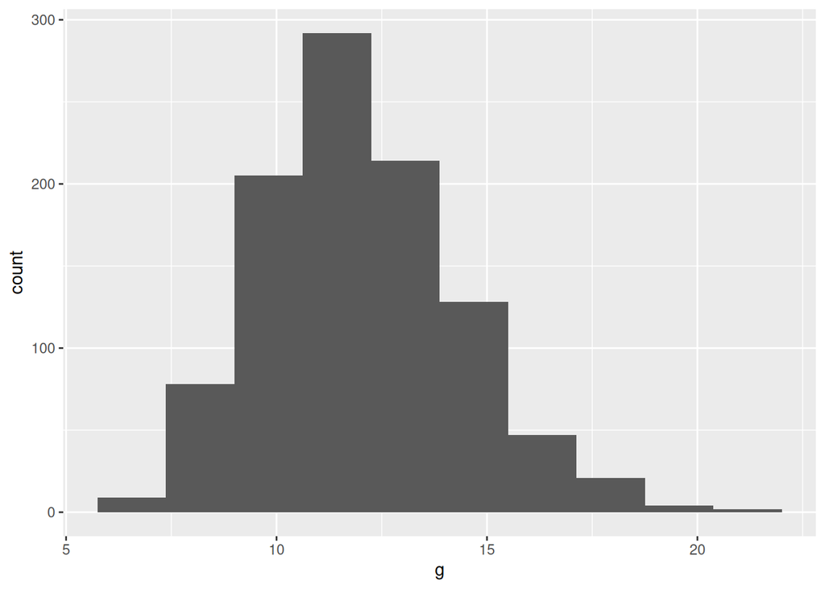

```r
ggplot(d, aes(x = g)) + geom_histogram(bins = 10)
```

This is very slightly skewed to the right, but it is not that far away from being normal.

A normal quantile plot should tell the same story:

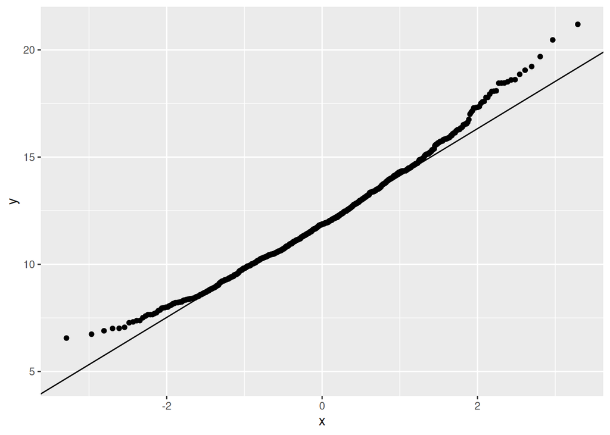

```r
ggplot(d, aes(sample = g)) + stat_qq() + stat_qq_line()
```

This is not far from normal (points all fairly close to the line), but the lowest values don’t go down far enough, and the highest ones are too high: that is, the distribution is somewhat right-skewed. (Your random gamma values will most likely be different from mine, so your histogram, and normal quantile plot if you drew one, will also most likely be slightly different from mine, but they should have similar shapes to mine.)

I am expecting most people to have a slightly right-skewed histogram. Gamma distributions in general are right-skewed because of the lower limit of zero, but you can see that this one doesn’t get very close to zero, so the skewness is rather mild.

$\blacksquare$

12. Suppose now that you want to assume that the data have a gamma distribution with this scale and shape (and thus the same mean and SD that you used previously). Modify your simulation to estimate the power of the $t$-test against a null mean of 11 against the alternative that the mean is greater than 11, using a sample size of 20, with the data coming from this gamma distribution.

Solution

`power.t.test` assumes normally-distributed data, which we no longer want to assume, and so we cannot use that. (We are still doing a $t$-test, so that part is not a problem.)

In the first simulation from these data, there is actually only one line that needs to change, the third one, which generates the random samples from the truth. Instead of `rnorm`, this should have `rgamma`, using the shape and scale values from above, but with a sample size of 20. The test is the same, with the same hypotheses, so nothing else changes:

```r
tibble(sim = 1:1000) %>%
  rowwise() %>%
  mutate(my_sample = list(rgamma(20, shape = 27.23, scale = 0.44))) %>%
  mutate(t_test = list(t.test(my_sample, mu = 11, alternative = "greater"))) %>%
  mutate(p_val = t_test$p.value) %>%
  count(p_val <= 0.05)
```

| p_val <= 0.05 | n |
| --- | --- |
| FALSE | 414 |
| TRUE | 586 |

Copy, paste, and edit from what you did before. Here, change the `rnorm` to `rgamma` and put the right numbers in.

My estimated power is 0.586.

$\blacksquare$

13. Compare the estimated power from earlier and the previous part. Does the similarity or difference make sense? Explain briefly.

Solution